# Act_Report

Analysing the data which has been pulled from Twitter's WeRateDogs. As part of the Udacity Data Analyst Nanodegree

```python
# import libraries
import tweepy
import pandas as pd
import numpy as np
import requests
import os
import re
import time
import json
from PIL import Image
from io import BytesIO
from nltk import pos_tag
import matplotlib
import matplotlib.pyplot as plt
%matplotlib inline
matplotlib.style.use('seaborn-whitegrid')
```

```python
full_data = pd.read_csv("all_twitter_data.csv")
```

## Anlaysis on twitter data created

Conducting overview analysis on the data identified from the project to understand key trends or future aspects to investigate

### Visualisation 1:

Starting to look at the analysis of tweets with a split in gender as per the chart below. It's clear that there are 30% female dogs as compared to 70% tweets made for male dogs. This could be for a variety of reasons:

**1)** more male dog owners use twitter

**2)** the website favours male tweets

**3)** the text strings weren't converted correctly

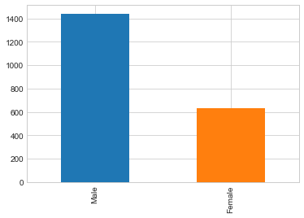

```python
full_data[full_data.gender.notnull()]['gender'].value_counts().plot(kind='bar')
```

### Visualisation 2: Breed of dogs

Creating a data set to deep dive into the breed data and compare it to some of the quantifiable variables i.e. retweets/favorites/ratings

```
Text(0,0.5,'breeds')
```

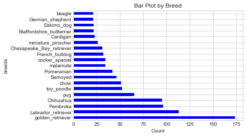

```python
# creating new data set
breed_split = full_data[full_data['breed']!='Not Identified']
breed_split = breed_split.groupby('breed').filter(lambda x:len(x)>20)
breed_split.breed.value_counts().plot(kind='barh',color='blue')
plt.title('Bar Plot by Breed')
plt.xlabel('Count')
plt.ylabel('breeds')
```

The graph above highlights that the predictive model identified the largest number of posts were made for golden retrievers making up almost 18% of all identified dog breeds. To better understand the impact of breed, I am going to cross-reference it against ratings

```python
breed_split.groupby('breed')['rating_numerator'].describe()
```

| breed | count | mean | std | min | 25% | 50% | 75% | max |
| --- | --- | --- | --- | --- | --- | --- | --- | --- |
| Cardigan | 23.0 | 11.173913 | 1.527094 | 7.0 | 10.50 | 11.0 | 12.00 | 13.0 |
| Chesapeake_Bay_retriever | 31.0 | 10.838710 | 1.439833 | 8.0 | 10.00 | 10.0 | 12.00 | 13.0 |
| Chihuahua | 95.0 | 10.610526 | 2.089970 | 3.0 | 10.00 | 11.0 | 12.00 | 14.0 |
| Eskimo_dog | 22.0 | 11.409091 | 1.402688 | 9.0 | 10.00 | 12.0 | 12.00 | 14.0 |
| French_bulldog | 32.0 | 11.281250 | 1.835745 | 8.0 | 10.00 | 12.0 | 12.25 | 14.0 |
| German_shepherd | 21.0 | 11.000000 | 1.449138 | 8.0 | 10.00 | 11.0 | 12.00 | 13.0 |
| Labrador_retriever | 113.0 | 13.530973 | 16.422475 | 7.0 | 10.00 | 11.0 | 12.00 | 165.0 |
| Pembroke | 96.0 | 11.427083 | 1.715225 | 4.0 | 11.00 | 12.0 | 12.00 | 14.0 |
| Pomeranian | 42.0 | 12.476190 | 9.978607 | 6.0 | 10.00 | 11.0 | 12.00 | 75.0 |
| Samoyed | 46.0 | 11.717391 | 1.327706 | 7.0 | 11.00 | 12.0 | 13.00 | 14.0 |
| Staffordshire_bullterrier | 22.0 | 10.863636 | 1.424127 | 8.0 | 10.00 | 11.0 | 12.00 | 13.0 |
| beagle | 21.0 | 10.238095 | 1.546116 | 6.0 | 10.00 | 10.0 | 11.00 | 13.0 |
| chow | 51.0 | 14.039216 | 18.611782 | 7.0 | 11.00 | 12.0 | 12.00 | 144.0 |
| cocker_spaniel | 34.0 | 11.470588 | 1.186676 | 9.0 | 11.00 | 12.0 | 12.00 | 13.0 |
| golden_retriever | 173.0 | 12.901734 | 12.066996 | 5.0 | 11.00 | 12.0 | 12.00 | 143.0 |
| malamute | 34.0 | 10.882353 | 1.200119 | 8.0 | 10.00 | 11.0 | 12.00 | 13.0 |
| miniature_pinscher | 26.0 | 10.076923 | 2.544375 | 2.0 | 9.25 | 11.0 | 12.00 | 12.0 |
| pug | 65.0 | 10.307692 | 1.802109 | 3.0 | 10.00 | 10.0 | 11.00 | 13.0 |
| toy_poodle | 52.0 | 11.057692 | 1.258905 | 7.0 | 10.00 | 11.0 | 12.00 | 13.0 |

Interestingly, golden retrievers do not have the highest mean. Furthermore golden retrievers have a abnormally high SD which means the data has a very high range. This is further evident through the max and min being so spread. The cause of this is the overly large numerators some of the tweets have recieved. This trend can also be seen with Chows and labrador retrievers where the max is 140+.

To create a more normally distributed dataset, I am going to remove the outliers (anything above a rating of 14 from my calculations.

```python
breed_split[breed_split.rating_numerator>14].breed.value_counts()
```

```
Labrador_retriever    3
golden_retriever      3
chow                  1
Pomeranian            1
Name: breed, dtype: int64
```

```python
breed_split = breed_split[breed_split.rating_numerator<=14]
```

```python
breed_split.groupby('breed')['rating_numerator'].describe()
```

| breed | count | mean | std | min | 25% | 50% | 75% | max |
| --- | --- | --- | --- | --- | --- | --- | --- | --- |
| Cardigan | 23.0 | 11.173913 | 1.527094 | 7.0 | 10.50 | 11.0 | 12.00 | 13.0 |
| Chesapeake_Bay_retriever | 31.0 | 10.838710 | 1.439833 | 8.0 | 10.00 | 10.0 | 12.00 | 13.0 |
| Chihuahua | 95.0 | 10.610526 | 2.089970 | 3.0 | 10.00 | 11.0 | 12.00 | 14.0 |
| Eskimo_dog | 22.0 | 11.409091 | 1.402688 | 9.0 | 10.00 | 12.0 | 12.00 | 14.0 |
| French_bulldog | 32.0 | 11.281250 | 1.835745 | 8.0 | 10.00 | 12.0 | 12.25 | 14.0 |
| German_shepherd | 21.0 | 11.000000 | 1.449138 | 8.0 | 10.00 | 11.0 | 12.00 | 13.0 |
| Labrador_retriever | 110.0 | 11.200000 | 1.325820 | 7.0 | 10.00 | 11.0 | 12.00 | 14.0 |
| Pembroke | 96.0 | 11.427083 | 1.715225 | 4.0 | 11.00 | 12.0 | 12.00 | 14.0 |
| Pomeranian | 41.0 | 10.951220 | 1.395550 | 6.0 | 10.00 | 11.0 | 12.00 | 14.0 |
| Samoyed | 46.0 | 11.717391 | 1.327706 | 7.0 | 11.00 | 12.0 | 13.00 | 14.0 |
| Staffordshire_bullterrier | 22.0 | 10.863636 | 1.424127 | 8.0 | 10.00 | 11.0 | 12.00 | 13.0 |
| beagle | 21.0 | 10.238095 | 1.546116 | 6.0 | 10.00 | 10.0 | 11.00 | 13.0 |
| chow | 50.0 | 11.440000 | 1.372619 | 7.0 | 11.00 | 12.0 | 12.00 | 13.0 |
| cocker_spaniel | 34.0 | 11.470588 | 1.186676 | 9.0 | 11.00 | 12.0 | 12.00 | 13.0 |
| golden_retriever | 170.0 | 11.564706 | 1.286682 | 5.0 | 11.00 | 12.0 | 12.00 | 14.0 |
| malamute | 34.0 | 10.882353 | 1.200119 | 8.0 | 10.00 | 11.0 | 12.00 | 13.0 |
| miniature_pinscher | 26.0 | 10.076923 | 2.544375 | 2.0 | 9.25 | 11.0 | 12.00 | 12.0 |
| pug | 65.0 | 10.307692 | 1.802109 | 3.0 | 10.00 | 10.0 | 11.00 | 13.0 |
| toy_poodle | 52.0 | 11.057692 | 1.258905 | 7.0 | 10.00 | 11.0 | 12.00 | 13.0 |

```python
breed_split['rating_numerator'].describe()
```

```
count    991.000000
mean      11.120081
std        1.601360
min        2.000000
25%       10.000000
50%       11.000000
75%       12.000000
max       14.000000
Name: rating_numerator, dtype: float64
```

```
1) Chows were the leader in ratings with an average of 14
2) Labrador retrievers were second at 13.5
```

After standardising:

[output not shown]

### Visualisation 3: Gender and Dog type

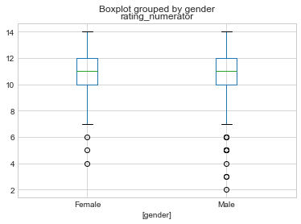

```python
breed_split.boxplot(column=['rating_numerator'],by=['gender'])
```

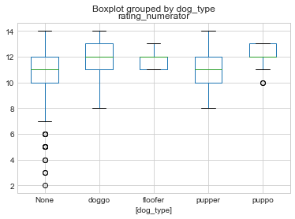

```python
breed_split.boxplot(column=['rating_numerator'],by=['dog_type'])
```

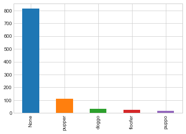

```python
breed_split.dog_type.value_counts().plot('bar')
```

When comparing ratings against gender, both categories seem to do recieve relevantly equal ratings when looking at the quartiles and IQR. Males have a longer tail but this may be caused by the larger number of male tweets posted.

Furthermore, when deep diving into the dog types, it's clear that Puppo's have the highest average rating for any dog type. Although interestingly, puppo's also do not have a upper tail, due to the smaller number of entries for puppos. Essentially this means that all puppos get a very strong rating.